# Diplomado en Análisis de datos con R para la acuicultura

15/4/2021

**PLAN DE LA CLASE**

**1).** **Palabras de Bienvenida**.

**2).** **Presentación de los participantes**.

**3).** **Programa del curso**.

**4).** **Habilitar recursos de aprendizaje**.

**PROFESORES**

[figure not shown]

**Dr. José Gallardo**

Profesor adjunto PUCV

Doctor en Ciencias

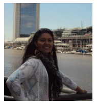

**Dr. María Angélica Rueda**

Investigadora PUCV

Doctor en Ciencias Agropecuarias

**PRESENTACIÓN Y REVISIÓN DEL PROGRAMA DEL CURSO**

**DESCRIPCIÓN Y PRERREQUISITOS**

El *Diplomado en análisis de datos con R para la acuicultura* tiene como propósito que los estudiantes desarrollen habilidades para llevar a cabo un proyecto de análisis de datos e investigación reproducible en acuicultura usando el lenguaje de programación **R**.

- **Bioestadística.**
- **Programación en R.**

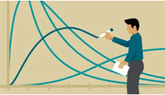

**FECHAS DE CLASES**

**Presentación del diplomado y evaluación diagnóstica**

Jueves 15 de abril - 19:00 - 20:00 P.M.

**Clases sincrónicas**

Martes y jueves de 19:00 - 21:00 P.M.

**20,22,27,29 de abril**

**4,6,11,13,18,20,25,27 de mayo**

**1,3,8,10,15,17,22,24,29 de junio**

**6,8,13,15,20,22,26 de julio**

**Cierre del diplomado y entrega de certificados de aprobación** Jueves 12 de agosto -19:00 - 20:00 P.M.

**CONTENIDOS CENTRALES**

**UNIDAD 1**

INVESTIGACIÓN REPRODUCIBLE Y ANÁLISIS EXPLORATORIO DE DATOS.

**UNIDAD 2**

CONTRASTES DE HIPÓTESIS PARAMÉTRICAS Y NO PARAMÉTRICAS.

**UNIDAD 3**

MODELOS LINEALES Y ANÁLISIS MULTIVARIADO.

**UNIDAD 4**

PROYECTO PERSONAL Y ANÁLISIS DE DATOS CON **R**.

**COMPONENTES DE EVALUACIÓN**

**1).** **Tareas de autoaprendizaje:** Número variable de tareas de autoaprendizaje asignadas por el profesor mediante la plataforma **[DataCamp](https://www.datacamp.com/)**.

**2).** **Tareas de evaluación de competencias:** Cuatro tareas de resolución de problemas o ejercicios en forma individual, una para cada unidad.

**3).** **Nota de aprobación:** La nota final de aprobación es un **4,0** con un 60% de exigencia, la que se calculará como el promedio simple de las 4 tareas de evaluación de competencias.

**4).** **Calificación por no entrega de tareas:** No entregar las tareas en el plazo establecido para ello será calificado con la nota mínima **(1,0)**.

**5).** **Causales de reprobación:** 1) Promedio menor a **4,0** en las tareas de evaluación de competencias, b) No realizar el **100%** de las tareas de autoaprendizaje, c) Asistencia a clases sincrónicas menor al **75%**.

**RECURSOS DE APRENDIZAJE**

**CORREO MAIL PUCV**

[figure not shown]

**FORO DE PREGUNTAS - SLACK**

[figure not shown]

**CUENTA EN DATACAMP**

[figure not shown]

**CUENTA EN R STUDIO CLOUD:** *PRÓXIMO MARTES*

[figure not shown]

**TAREA SEMANA 1**

[figure not shown]